# WB-XAI-2 Praca domowa 3

Janus Dawid

25 03 2021

## Wczytanie danych

```r
blood <- read.csv("D:/Studia/Projekty/R-projekty/blood.csv",
                   header = TRUE)

head(blood)
```

```
##   V1 V2    V3 V4 Class
## 1  2 50 12500 98     2
## 2  0 13  3250 28     2
## 3  1 16  4000 35     2
## 4  2 20  5000 45     2
## 5  1 24  6000 77     1
## 6  4  4  1000  4     1
```

## Informacje o danych

- V1: Recency - months since last donation
- V2: Frequency - total number of donation
- V3: Monetary - total blood donated in c.c.
- V4: Time - months since first donation)
- Class: The target attribute is a binary variable representing whether he/she donated blood in March 2007 (2 stands for donating blood; 1 stands for not donating blood).

## Zmiana nazw kolumn

```r
names(blood) <- c("Recency", "Frequency", "Monetary", "Time", "Class")

blood<-blood %>% mutate(Class=as.integer(Class-1))


head(blood)
```

```
##   Recency Frequency Monetary Time Class
## 1       2        50    12500   98     1
## 2       0        13     3250   28     1
## 3       1        16     4000   35     1
## 4       2        20     5000   45     1
## 5       1        24     6000   77     0
## 6       4         4     1000    4     0
```

## Tworzenie modelu

```r
classif_task <- makeClassifTask(data = blood, target = "Class")
classif_lrn <- makeLearner("classif.ranger", predict.type = "prob")
model_mlr <- train(classif_lrn, classif_task)
```

## Utworzenie explainera

```r
explainer <- explain(model = model_mlr,
                     data = blood[,-5],
                     y = blood[,5])
```

```
## Preparation of a new explainer is initiated
##   -> model label       :  WrappedModel  (  default  )
##   -> data              :  748  rows  4  cols
##   -> target variable   :  748  values
##   -> predict function  :  yhat.WrappedModel  will be used (  default  )
##   -> predicted values  :  numerical, min =  0.002836525 , mean =  0.2390175 , max =  0.9064366
##   -> model_info        :  package mlr , ver. 2.19.0 , task classification (  default  )
##   -> residual function :  difference between y and yhat (  default  )
##   -> residuals         :  numerical, min =  -0.681554 , mean =  -0.001049613 , max =  0.9420499
##   A new explainer has been created!
```

## Wyświetlenie jednej obserwacji

```r
prep  <-predict(model_mlr, newdata = blood[1,])$data$prob.1
prep
```

```
## [1] 0.7249198
```

```r
blood[1,5]
```

```
## [1] 1
```

## Dekompozycja predykcji modelu Ceteris Paribus dla wybranej obserwacji

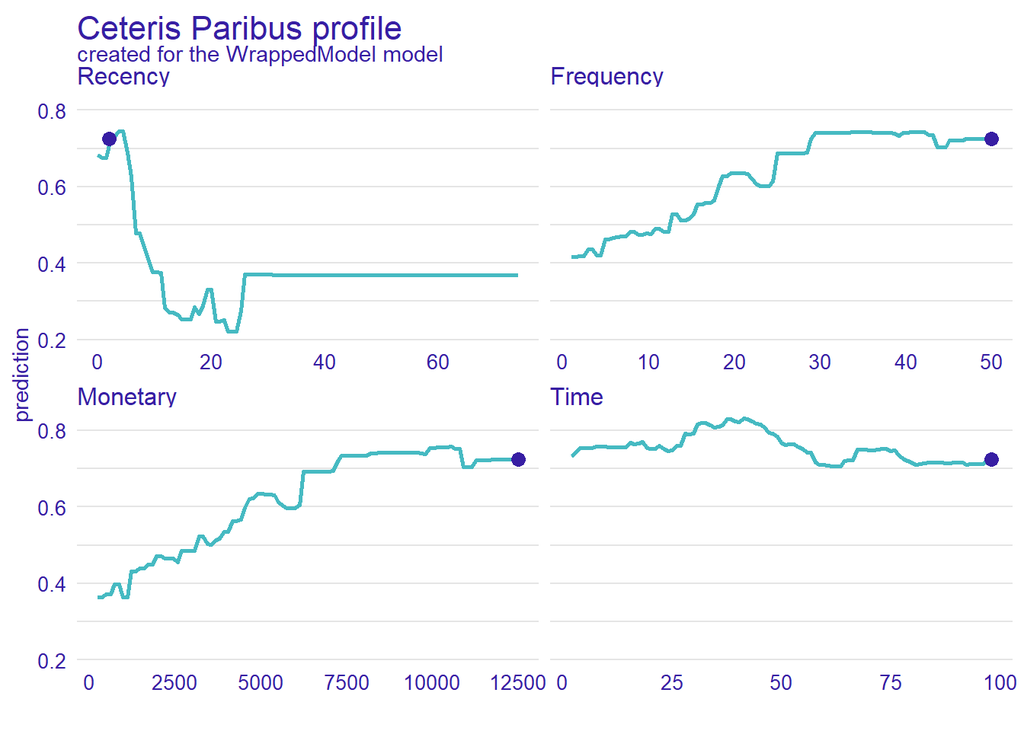

```r
cp_2 <- predict_profile(explainer, blood[1,])
plot(cp_2)
```

Obserwacja numer 1 ma dużą wartość zmiennych *Frequency*, *Monetary* oraz *Time*, natomiast małe *Recency*. Co ciekawe predykcja modelu dla tej obserwacji różni sie bardzo mało w zależności od zmiennej *Time*. Możliwe, że wpływa na to duża wartość zmiennych *Monetary* oraz *Frequency* i czas od pierwszego oddania krwi nie jest już taki ważny.

## Porównanie dwóch obserwacji

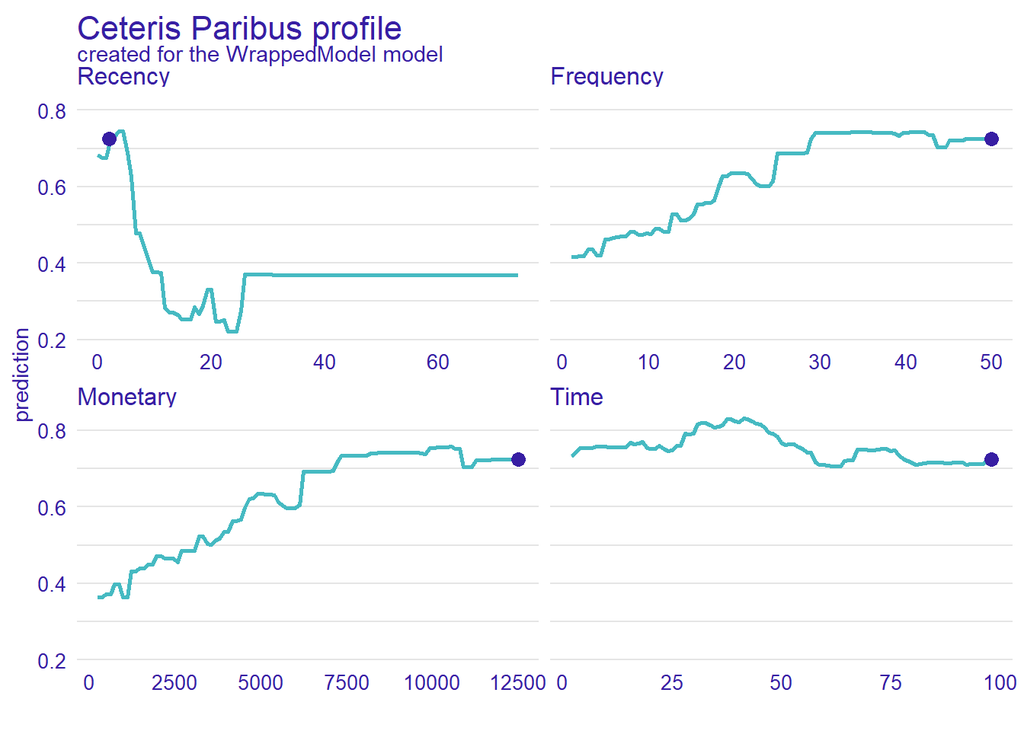

```r
cp_1 <- predict_profile(explainer, blood[1,])
plot(cp_1)
```

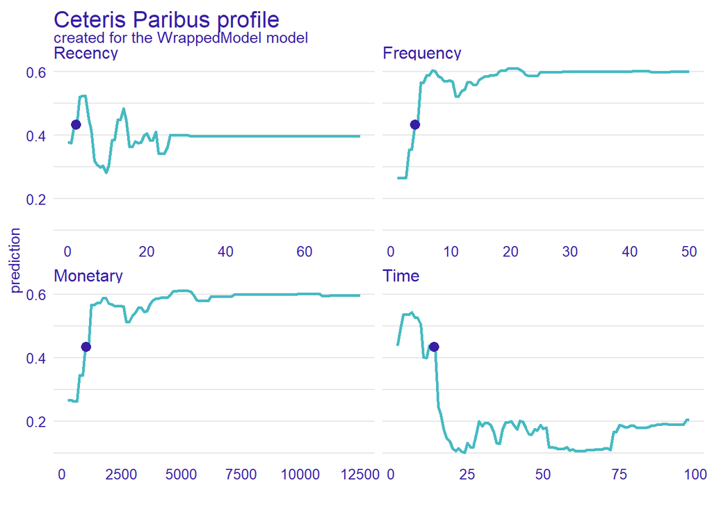

```r
cp_2 <- predict_profile(explainer, blood[532,])
plot(cp_2)
```

Patrząc na obie obserwacji od razu widać zupełnie inny kształt wykresu *Time*. W przypadku obserwacji pierwszej wykres jest praktycznie stały. Sytuacja przedstawia sie inaczej w drugiej obserwacji. Widzimy duży spadek predykcji, gdy *Time* wynosi 20, a następnie waha sie w przedziale 0.0-0.2. Prawdopodobnie wpływ na różnice tych 2 wykresów miały zmienne *Frequency* oraz *Monetary*. W przypadku obserwacji pierwszej były one duże, więc czas od pierwszego oddania krwi nie jest aż tak znaczący, przeciwnie do sytuacji w obserwacji 2.